# Exercise 5, MLaRP Week 4

Hanne Oberman

11-11-2019

# Simulate the Data

Sample 100 samples from a standard normal distribution.

```r
# param
numsim <- 100
n <- 1000

# generate data
simulate.function <- function(numsim, n) {
  data <- list()
  for (i in 1:numsim) {
    data[[i]] <- rnorm(n)
  }
  return(data)
}

data <- simulate.function(numsim = 100, n = 10)
```

# Calculate Sample Statistics

For each of these samples, calculate the following statistics for the mean: 1) absolute bias; 2) standard error; 3) lower bound of the 95% confidence interval; and 4) upper bound of the 95% confidence interval.

1. Absolute bias (AB) is calculated as
   $$AB = |\bar{x} - \mu|,$$
   where $\bar{x}$ is the sample mean, and $\mu$ is the population mean. In this example the poplation mean is known to be zero. Hence, the absolute bias is just the sample mean (minus the sign).
2. To calculate standard errors, we need the sample variance, $s^2$. Sample variance is defined as
   $$s^2 = \frac{\Sigma(x_i-\bar{x})^2}{n-1},$$
   where $x_i$ are individual observations, $\bar{x}$ and $n$ are sample mean and sample size, respectively. Then, take the square root of the sample variance to get the sample standard deviation:
   $$s = \sqrt{s^2}.$$
   Finally, divide the sample standard deviation by the square root of the sample size to get the standard error:
   $$SE = \frac{s}{\sqrt{n}}.$$
3. The lower bound of the 95% confidence interval is calulated by multiplying the standard error by the z-value of alpha divided by two, and subtracting this from the sample mean:
   $$\text{Lower bound (LB) } CI_{95\%} = \bar{x} - SE \times z_{\alpha/2}.$$
4. Similarly, we add the standard error times the z-value to the sample mean to get the upper bound of the 95% CI:

$$\text{Upper bound (UB) } CI_{95\%} = \bar{x} + SE \times z_{\alpha/2}.$$

```r
# evaluate simulations
evaluate.function <- function(x, alpha = .05) {
  z_value <- qnorm(p = (alpha / 2), lower.tail = F)
  means <- mean(x)
  bias <- abs(means)
  se <- var(x) %>%
    sqrt() / sqrt(length(x))
  ci_low <- means - se * z_value
  ci_up <- means + se * z_value
  return(c(
    mean = means,
    bias = bias,
    se = se,
    ci_low = ci_low,
    ci_up = ci_up
  ))
}

# extract results
result <- data %>%
  sapply(evaluate.function) %>%
  t() %>%
  as.data.frame()

result$cov <- result$ci_low <= 0 & result$ci_up >= 0
```

# Evaluate the Samples

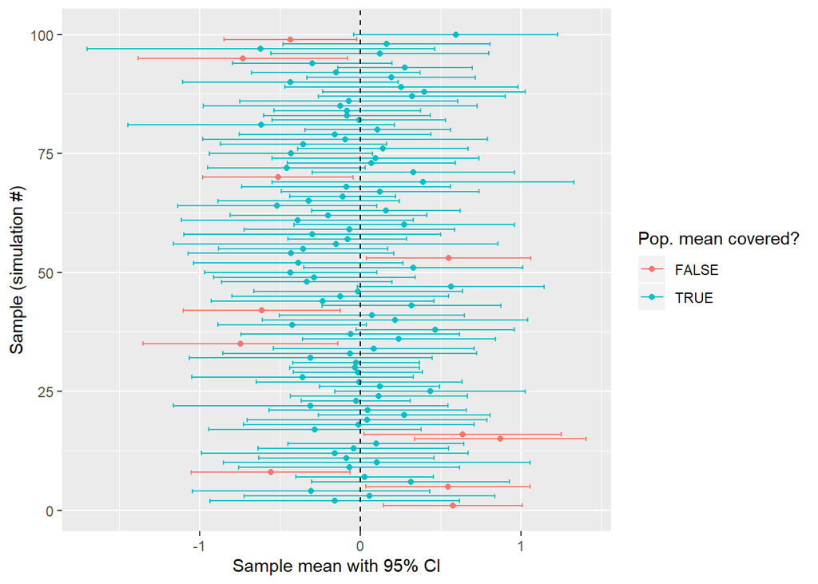

```r
# plot results
result %>%
  ggplot(aes(
    y = 1:numsim,
    x = mean,
    xmin = ci_low,
    xmax = ci_up,
    color = cov
  )) +
  geom_point() +
  geom_errorbarh() +
  geom_vline(xintercept = 0,
             color = 'black',
             linetype = 'dashed') +
  xlab('Sample mean with 95% CI') +
  ylab('Sample (simulation #)') +
  labs(color = 'Pop. mean covered?')
```

# Inspect a Subset of Samples

Present a table containing all simulated samples for which the resulting confidence interval does not contain the population value.

```r
# extract simulations where CI does not cover the 'truth'
result %>%
  mutate(sim = row.names(.)) %>%
  filter(cov == "FALSE") %>%
  select("Sample" = sim, "Mean" = mean, "SE" = se, "LB*" = ci_low, "UB*" = ci_up) %>%
  kable(format = 'html', digits = 2, align = 'lcccc')
```

| Sample | Mean | SE | LB* | UB* |
| --- | --- | --- | --- | --- |
| 1 | 0.58 | 0.22 | 0.15 | 1.01 |
| 5 | 0.55 | 0.26 | 0.04 | 1.06 |
| 8 | -0.56 | 0.25 | -1.05 | -0.06 |
| 15 | 0.87 | 0.27 | 0.34 | 1.41 |
| 16 | 0.64 | 0.31 | 0.02 | 1.25 |
| 35 | -0.75 | 0.31 | -1.35 | -0.14 |
| 42 | -0.61 | 0.25 | -1.10 | -0.13 |
| 53 | 0.55 | 0.26 | 0.04 | 1.06 |
| 70 | -0.51 | 0.24 | -0.98 | -0.04 |
| 95 | -0.73 | 0.33 | -1.38 | -0.08 |
| 99 | -0.44 | 0.21 | -0.85 | -0.02 |

*LB: lower bound of the 95% confidence interval; UB: lower bound of the 95% confidence interval.